# 3D chromatin: are HFD-opened AP-1 peaks in GR-bound TADs?

Stage 1 — TAD-level enrichment of measured GR occupancy at HFD-specific open chromatin (GSE236575 × GSE95533 × GR ChIP)

Author

Dave Bridges

Published

June 4, 2026

```r
library(GenomicRanges)
library(GenomeInfoDb)
library(rtracklayer)
library(dplyr)
library(tidyr)
library(tibble)
library(readr)
library(stringr)
library(purrr)
library(ggplot2)

select <- dplyr::select        # AnnotationDbi/GenomicRanges mask dplyr::select (see MEMORY)
set.seed(1)

atac_dir <- "../snATACseq/GSE236575/results/deseq2"        # GSE236575 ATAC classes (mm10)
gr_dir   <- "../GR-ChIPseq/results/peaks"                   # GR ChIP consensus peaks (mm10)
chain    <- "../GR-ChIPseq/hg38ToMm10.over.chain"           # human fallback chain
tad_dir  <- "results/tads"                                  # synced-back mm10 TAD BEDs
out_dir  <- "results/enrichment"
dir.create(out_dir, showWarnings = FALSE, recursive = TRUE)

# Primary TAD set: D2 3T3-L1, cooltools-insulation caller, lifted to mm10.
# Sensitivity set: same matrix, HiCExplorer caller.
tad_primary  <- file.path(tad_dir, "D2_insulation_tads.mm10.bed")
tad_sensitiv <- file.path(tad_dir, "D2_hicexplorer_tads.mm10.bed")
```

# Question

GSE236575 found AP-1 (Junb-led) opens HFD-specific chromatin, and predicted AP-1+GR composite motifs are enriched there (Fisher OR = 1.28). But the GR-ChIPseq sub-project showed *measured* GR occupancy is **depleted** at those same HFD-specific peaks (eWAT strain-reproducible OR = 0.09) — GR concentrates on constitutive/closing chromatin instead. The reconciling hypothesis is **3D**: HFD-opened AP-1 enhancers act on GR-mediated transcription by **looping to a GR-bound promoter elsewhere in the same TAD**, not by direct co-binding.

**H1 (this report):** HFD-specific ATAC peaks sit in TADs that contain GR-bound elements *more often than* shared (non-differential) peaks do.

- **OR > 1** → the 3D-rescue hypothesis is supported; reframe proposal Arm 2.
- **OR ≈ 1** → not supported; the local 151-peak claim stands (defer to H3).
- **OR < 1** → HFD remodels chromatin preferentially in non-GR TADs (also mechanistically interesting).

TADs are from 3T3-L1 **D2** Hi-C (GSE95533) — the most adipocyte-committed Hi-C available; see *Caveats*. Genome assembly mm10 throughout (TADs lifted mm9→mm10).

```r
have_tads <- file.exists(tad_primary)
if (!have_tads) {
  cat(
"::: callout-important\n",
"**TAD BED not present yet.** Run `main.nf` on Great Lakes and sync the mm10 TAD\n",
"BEDs into `", tad_dir, "/` (at minimum `D2_insulation_tads.mm10.bed`). This\n",
"report then renders the full Stage 1 enrichment. Until then the analysis blocks\n",
"below are skipped.\n:::\n", sep = "")
}
knitr::opts_chunk$set(eval = have_tads)
```

# Load inputs

```r
# BEDs are 0-based half-open → +1 to start for 1-based GRanges.
clean <- function(gr) keepStandardChromosomes(gr, pruning.mode = "coarse")

read_bed3 <- function(path) {
  readr::read_tsv(path, col_names = c("chr","start","end"),
                  col_types = "cii", progress = FALSE) |>
    with(GRanges(chr, IRanges(start + 1L, end))) |> clean()
}

read_narrowpeak <- function(path) {
  cn <- c("chr","start","end","name","score","strand","signal","pval","qval","peak")
  readr::read_tsv(path, col_names = cn, col_types = "ciicicdddi", progress = FALSE) |>
    with(GRanges(chr, IRanges(start + 1L, end))) |> clean()
}
```

```r
atac <- list(
  HFD_specific = read_bed3(file.path(atac_dir, "HFD_specific_peaks.bed")),
  CHD_specific = read_bed3(file.path(atac_dir, "CHD_specific_peaks.bed")),
  shared       = read_bed3(file.path(atac_dir, "shared_peaks.bed"))
)
map_int(atac, length)
```

```
HFD_specific CHD_specific       shared
        6899         1322        53378
```

```r
# Same GR sets as the GR-ChIPseq sub-project, so Stage 1 is directly comparable.
gr_union <- list(
  eWAT_union = read_bed3(file.path(gr_dir, "GSE64458_eWAT/GSE64458_eWAT_GR_consensus.bed")),
  iWAT_union = read_bed3(file.path(gr_dir, "GSE64458_iWAT/GSE64458_iWAT_GR_consensus.bed"))
)

# Strain-reproducible (B6 ∩ 129) high-confidence mouse sets — the specificity-
# appropriate readout used in GR-ChIPseq.
reproducible <- function(a_path, b_path) {
  a <- read_narrowpeak(a_path); b <- read_narrowpeak(b_path)
  GenomicRanges::reduce(c(IRanges::subsetByOverlaps(a, b), IRanges::subsetByOverlaps(b, a)))
}
gr_repro <- list(
  eWAT_repro = reproducible(
    file.path(gr_dir, "GSE64458_eWAT/GSE64458_B6_eWAT_GR_peaks.narrowPeak"),
    file.path(gr_dir, "GSE64458_eWAT/GSE64458_129_eWAT_GR_peaks.narrowPeak")),
  iWAT_repro = reproducible(
    file.path(gr_dir, "GSE64458_iWAT/GSE64458_B6_iWAT_GR_peaks.narrowPeak"),
    file.path(gr_dir, "GSE64458_iWAT/GSE64458_129_iWAT_GR_peaks.narrowPeak"))
)

# Human dex (tier-3, cross-species): pipeline-lifted mm10 consensus if present.
hs_path <- file.path(gr_dir, "GSE163061_human/GSE163061_human_GR_consensus.mm10.bed")
gr_sets <- c(gr_union, gr_repro)
if (file.exists(hs_path)) gr_sets$human_dex <- read_bed3(hs_path)
tibble(gr_set = names(gr_sets), n_peaks = map_int(gr_sets, length))
```

| gr_set | n_peaks |
| --- | --- |
| eWAT_union | 115086 |
| iWAT_union | 108197 |
| eWAT_repro | 60323 |
| iWAT_repro | 62660 |
| human_dex | 5301 |

```r
tads <- list(insulation = read_bed3(tad_primary))
if (file.exists(tad_sensitiv)) tads$hicexplorer <- read_bed3(tad_sensitiv)
tibble(caller = names(tads),
       n_tads = map_int(tads, length),
       median_width_kb = map_dbl(tads, ~ median(width(.x)) / 1e3),
       genome_cov_pct  = map_dbl(tads, ~ 100 * sum(as.numeric(width(.x))) / 2.5e9))
```

| caller | n_tads | median_width_kb | genome_cov_pct |
| --- | --- | --- | --- |
| insulation | 2746 | 650 | 96.89489 |
| hicexplorer | 3086 | 650 | 96.91721 |

# Assign peaks and GR sites to TADs

Each ATAC peak is assigned to the TAD containing its **midpoint** (unique assignment, robust to peaks straddling a boundary). Peaks whose midpoint falls in an inter-TAD gap are unassigned and dropped from the per-peak test (reported).

```r
midpoints <- function(gr) resize(gr, width = 1, fix = "center")

# host TAD index for each peak (NA if midpoint in an inter-TAD gap)
host_tad <- function(peaks, tad) {
  hits <- findOverlaps(midpoints(peaks), tad, select = "first")
  hits
}
```

```r
# Beta-binomial posterior OR (Jeffreys priors) — same estimator as GR-ChIPseq.
posterior_or <- function(k_fg, n_fg, k_bg, n_bg, a = 0.5, b = 0.5, ndraw = 2e5) {
  p_fg <- rbeta(ndraw, a + k_fg, b + n_fg - k_fg)
  p_bg <- rbeta(ndraw, a + k_bg, b + n_bg - k_bg)
  or   <- (p_fg / (1 - p_fg)) / (p_bg / (1 - p_bg))
  tibble(or_post = median(or), cri_lo = unname(quantile(or, 0.025)),
         cri_hi = unname(quantile(or, 0.975)), p_or_gt1 = mean(or > 1))
}

# Build the full per-peak / per-TAD frame for one TAD caller.
build_frames <- function(tad, gr_sets) {
  # TAD-level GR counts
  tad_tb <- tibble(tad_id = seq_along(tad), tad_len = width(tad))
  for (g in names(gr_sets))
    tad_tb[[paste0("gr_", g)]] <- countOverlaps(tad, gr_sets[[g]])

  # per-peak host TAD + class
  peak_tb <- imap_dfr(atac, function(pk, cls) {
    h <- host_tad(pk, tad)
    tibble(class = cls, width = width(pk), tad_id = h)
  }) |>
    filter(class %in% c("HFD_specific", "shared")) |>
    left_join(tad_tb, by = "tad_id")

  list(tad = tad_tb, peak = peak_tb)
}

# Per-peak Fisher + Bayesian + width/length-adjusted logistic for one GR set.
peak_enrich <- function(peak_tb, gr_col, gr_name, caller) {
  # GR-rich TAD = GR count strictly above the median among TADs hosting any
  # tested peak (background-defined threshold, per the briefing).
  hosted <- peak_tb |> filter(!is.na(tad_id))
  thr <- median(hosted[[gr_col]], na.rm = TRUE)
  d <- hosted |> mutate(gr_rich = .data[[gr_col]] > thr,
                        class = relevel(factor(class), ref = "shared"))

  k_fg <- sum(d$gr_rich[d$class == "HFD_specific"]); n_fg <- sum(d$class == "HFD_specific")
  k_bg <- sum(d$gr_rich[d$class == "shared"]);       n_bg <- sum(d$class == "shared")
  ft   <- fisher.test(matrix(c(k_fg, n_fg - k_fg, k_bg, n_bg - k_bg), 2))

  # width + TAD-length adjusted logistic (class term is the adjusted effect)
  co <- summary(glm(gr_rich ~ class + log10(width) + log10(tad_len),
                    binomial, d))$coefficients["classHFD_specific", ]

  bind_cols(
    tibble(caller = caller, gr_set = gr_name, gr_rich_threshold = thr,
           pct_fg = 100 * k_fg / n_fg, pct_bg = 100 * k_bg / n_bg,
           or_fisher = unname(ft$estimate),
           ci_lo = ft$conf.int[1], ci_hi = ft$conf.int[2], p_fisher = ft$p.value,
           or_adj = exp(co[1]), adj_lo = exp(co[1] - 1.96 * co[2]),
           adj_hi = exp(co[1] + 1.96 * co[2]), p_adj = co[4]),
    posterior_or(k_fg, n_fg, k_bg, n_bg)
  )
}
```

```r
frames <- map(tads, build_frames, gr_sets = gr_sets)

per_peak <- imap_dfr(frames, function(fr, caller) {
  map_dfr(names(gr_sets), function(g)
    peak_enrich(fr$peak, paste0("gr_", g), g, caller))
}) |> arrange(caller, desc(or_post))

# unassigned-peak accounting
unassigned <- imap_dfr(frames, function(fr, caller) {
  fr$peak |> group_by(caller = caller, class) |>
    summarise(n = n(), unassigned = sum(is.na(tad_id)),
              pct_unassigned = 100 * mean(is.na(tad_id)), .groups = "drop")
})
unassigned
```

| caller | class | n | unassigned | pct_unassigned |
| --- | --- | --- | --- | --- |
| insulation | HFD_specific | 6899 | 233 | 3.377301 |
| insulation | shared | 53378 | 2025 | 3.793698 |
| hicexplorer | HFD_specific | 6899 | 256 | 3.710683 |
| hicexplorer | shared | 53378 | 2204 | 4.129042 |

```r
readr::write_tsv(per_peak, file.path(out_dir, "peak_in_gr_rich_tad.tsv"))
per_peak
```

| caller | gr_set | gr_rich_threshold | pct_fg | pct_bg | or_fisher | ci_lo | ci_hi | p_fisher | or_adj | adj_lo | adj_hi | p_adj | or_post | cri_lo | cri_hi | p_or_gt1 |
| --- | --- | --- | --- | --- | --- | --- | --- | --- | --- | --- | --- | --- | --- | --- | --- | --- |
| hicexplorer | human_dex | 1 | 43.68508 | 47.42643 | 0.8599205 | 0.8164538 | 0.9056525 | 8.912857e-09 | 0.7682277 | 0.7281898 | 0.8104670 | 4.671044e-22 | 0.8599428 | 0.8166486 | 0.9052701 | 0.000000 |
| hicexplorer | iWAT_repro | 29 | 24.11561 | 51.80756 | 0.2956248 | 0.2785585 | 0.3136149 | 0.000000e+00 | 0.2531634 | 0.2380885 | 0.2691929 | 0.000000e+00 | 0.2956373 | 0.2786017 | 0.3134113 | 0.000000 |
| hicexplorer | iWAT_union | 49 | 24.88334 | 52.85106 | 0.2955284 | 0.2786294 | 0.3133381 | 0.000000e+00 | 0.2444321 | 0.2298875 | 0.2598969 | 0.000000e+00 | 0.2955547 | 0.2787312 | 0.3131882 | 0.000000 |
| hicexplorer | eWAT_union | 52 | 24.49195 | 52.98589 | 0.2878112 | 0.2712798 | 0.3052691 | 0.000000e+00 | 0.2470661 | 0.2324514 | 0.2625997 | 0.000000e+00 | 0.2878350 | 0.2714164 | 0.3051766 | 0.000000 |
| hicexplorer | eWAT_repro | 27 | 23.67906 | 52.58334 | 0.2797778 | 0.2635393 | 0.2969156 | 0.000000e+00 | 0.2488549 | 0.2341187 | 0.2645185 | 0.000000e+00 | 0.2797890 | 0.2636408 | 0.2968414 | 0.000000 |
| insulation | human_dex | 1 | 49.21992 | 49.89777 | 0.9732423 | 0.9245070 | 1.0245497 | 3.037198e-01 | 0.7848959 | 0.7433843 | 0.8287255 | 2.405679e-18 | 0.9732522 | 0.9249022 | 1.0242685 | 0.148575 |
| insulation | iWAT_union | 50 | 27.96280 | 52.66294 | 0.3489208 | 0.3296888 | 0.3691963 | 0.000000e+00 | 0.2616376 | 0.2463061 | 0.2779234 | 0.000000e+00 | 0.3489213 | 0.3298144 | 0.3690467 | 0.000000 |
| insulation | iWAT_repro | 29 | 28.02280 | 52.79925 | 0.3480525 | 0.3288539 | 0.3682855 | 0.000000e+00 | 0.2755214 | 0.2595838 | 0.2924374 | 0.000000e+00 | 0.3480618 | 0.3289422 | 0.3680806 | 0.000000 |
| insulation | eWAT_union | 54 | 26.56766 | 52.17611 | 0.3316244 | 0.3130384 | 0.3511939 | 0.000000e+00 | 0.2683919 | 0.2527598 | 0.2849909 | 0.000000e+00 | 0.3316628 | 0.3132194 | 0.3510666 | 0.000000 |
| insulation | eWAT_repro | 28 | 24.82748 | 51.48482 | 0.3112291 | 0.2934294 | 0.3299631 | 0.000000e+00 | 0.2679822 | 0.2522975 | 0.2846419 | 0.000000e+00 | 0.3112230 | 0.2935621 | 0.3299172 | 0.000000 |

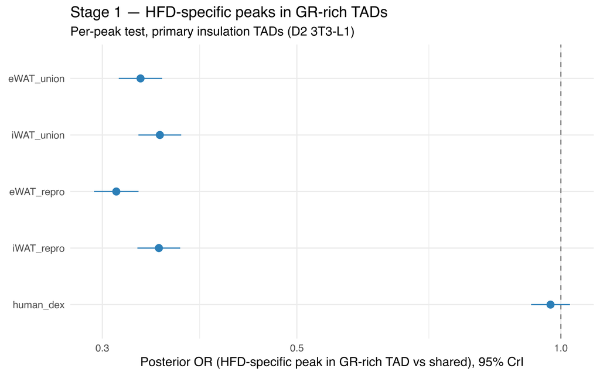

```r
per_peak |>
  filter(caller == "insulation") |>
  mutate(gr_set = factor(gr_set, levels = rev(names(gr_sets)))) |>
  ggplot(aes(or_post, gr_set)) +
  geom_vline(xintercept = 1, linetype = 2, colour = "grey50") +
  geom_pointrange(aes(xmin = cri_lo, xmax = cri_hi), colour = "#2c7fb8") +
  scale_x_log10() +
  labs(x = "Posterior OR (HFD-specific peak in GR-rich TAD vs shared), 95% CrI",
       y = NULL, title = "Stage 1 — HFD-specific peaks in GR-rich TADs",
       subtitle = "Per-peak test, primary insulation TADs (D2 3T3-L1)") +
  theme_minimal(base_size = 12)
```

```r
ggsave(file.path(out_dir, "tad_gr_enrichment_forest.pdf"), width = 8, height = 5)
```

# TAD-level Poisson — the genome-wide 3D claim in one number

Do TADs with more HFD-specific peaks contain more GR ChIP peaks? Poisson regression of per-TAD GR-peak count on per-TAD HFD-specific peak count, with TAD length as an offset (exposure). The HFD coefficient is the genome-wide 3D-rescue effect size.

```r
tad_counts <- function(fr) {
  # HFD-specific peaks per TAD
  hfd_n <- fr$peak |> filter(class == "HFD_specific", !is.na(tad_id)) |>
    count(tad_id, name = "n_hfd")
  fr$tad |> left_join(hfd_n, by = "tad_id") |>
    mutate(n_hfd = tidyr::replace_na(n_hfd, 0L))
}

poisson_one <- function(fr, gr_col, gr_name, caller) {
  d <- tad_counts(fr)
  m <- glm(as.formula(paste0(gr_col, " ~ n_hfd")),
           family = poisson, offset = log(tad_len), data = d)
  co <- summary(m)$coefficients["n_hfd", ]
  tibble(caller = caller, gr_set = gr_name,
         beta = co[1], se = co[2], irr = exp(co[1]),
         irr_lo = exp(co[1] - 1.96 * co[2]), irr_hi = exp(co[1] + 1.96 * co[2]),
         p = co[4])
}

tad_level <- imap_dfr(frames, function(fr, caller)
  map_dfr(names(gr_sets), ~ poisson_one(fr, paste0("gr_", .x), .x, caller))) |>
  arrange(caller, desc(irr))

readr::write_tsv(tad_level, file.path(out_dir, "tad_gr_enrichment.tsv"))
tad_level
```

| caller | gr_set | beta | se | irr | irr_lo | irr_hi | p |
| --- | --- | --- | --- | --- | --- | --- | --- |
| hicexplorer | human_dex | -0.02257641 | 0.005494679 | 0.9776765 | 0.9672039 | 0.9882626 | 3.977597e-05 |
| hicexplorer | iWAT_union | -0.06403596 | 0.001320735 | 0.9379713 | 0.9355463 | 0.9404025 | 0.000000e+00 |
| hicexplorer | iWAT_repro | -0.07249387 | 0.001763261 | 0.9300715 | 0.9268627 | 0.9332913 | 0.000000e+00 |
| hicexplorer | eWAT_union | -0.07300587 | 0.001302551 | 0.9295954 | 0.9272251 | 0.9319717 | 0.000000e+00 |
| hicexplorer | eWAT_repro | -0.08895752 | 0.001850603 | 0.9148844 | 0.9115720 | 0.9182089 | 0.000000e+00 |
| insulation | human_dex | -0.04977037 | 0.004265437 | 0.9514479 | 0.9435267 | 0.9594356 | 1.850983e-31 |
| insulation | iWAT_union | -0.09968120 | 0.001088495 | 0.9051259 | 0.9031969 | 0.9070590 | 0.000000e+00 |
| insulation | iWAT_repro | -0.10698952 | 0.001458202 | 0.8985351 | 0.8959707 | 0.9011068 | 0.000000e+00 |
| insulation | eWAT_union | -0.11048027 | 0.001085968 | 0.8954040 | 0.8935002 | 0.8973119 | 0.000000e+00 |
| insulation | eWAT_repro | -0.12711707 | 0.001564918 | 0.8806306 | 0.8779336 | 0.8833358 | 0.000000e+00 |

## Bayesian secondary (brms) — primary GR set

```r
# Set eval=TRUE to run (brms compiles a Stan model, ~1–2 min). Kept off by
# default so the report renders fast; the frequentist Poisson above is primary.
library(brms)
d <- tad_counts(frames$insulation)
fit <- brm(gr_eWAT_repro ~ n_hfd + offset(log(tad_len)),
           family = poisson(), data = d,
           prior = prior(normal(0, 1), class = "b"),
           chains = 4, cores = 4, iter = 2000, refresh = 0, seed = 1)
post <- as_draws_df(fit)
tibble(beta_med = median(post$b_n_hfd),
       cri_lo = quantile(post$b_n_hfd, 0.025),
       cri_hi = quantile(post$b_n_hfd, 0.975),
       p_beta_gt0 = mean(post$b_n_hfd > 0),
       irr_med = exp(median(post$b_n_hfd)))
```

# Predicted GR TFBS (motif identity) — does the depletion replicate?

The GR-ChIPseq result was framed as a discordance: *predicted* AP-1+GR composite motifs are enriched **within** HFD peaks (Fisher OR = 1.28) while *measured* GR occupancy is depleted there. That left an escape hatch — maybe the depletion is a property of GR *occupancy dynamics* (chow-only ChIP, basal-binding majority) and the AP-1-opened sites still sit in GR-*competent* neighborhoods. Here we close it: at the **TAD** scale, does the depletion also hold for GR binding **potential** (motif identity), independent of any ChIP?

We count GR-class motif sites (NR3C1 `MA0113.4` + Pgr/PGR IR3 `MA2323.1`/`MA2327.1`; FIMO p < 1e-4, from the GSE236575 scan) across accessible chromatin, define GR-motif-rich TADs the same way (count > median), and re-run the identical tests.

```r
mot_dir <- "../snATACseq/GSE236575/results/motif_analysis/composite_scan"
gr_motif_cols <- c("MA0113.4", "MA2323.1", "MA2327.1")   # NR3C1 + Pgr/PGR (GR-class)

# "chr:start-end" motif-table peak id → GRanges (TAD-scale; exact base offset irrelevant)
parse_peak <- function(x) {
  m <- str_match(x, "^(.*):([0-9]+)-([0-9]+)$")
  GRanges(m[, 2], IRanges(as.integer(m[, 3]), as.integer(m[, 4])))
}
read_motif_pos <- function(path) {
  m <- readr::read_tsv(path, show_col_types = FALSE, progress = FALSE)
  g <- parse_peak(m$peak)
  g$pos <- rowSums(as.matrix(m[, gr_motif_cols]) > 0) > 0   # any GR-class motif
  clean(g)
}
m_hfd <- read_motif_pos(file.path(mot_dir, "HFD_specific/HFD_specific_per_peak_motifs.tsv"))
m_chd <- read_motif_pos(file.path(mot_dir, "CHD_specific/CHD_specific_per_peak_motifs.tsv"))
m_shr <- read_motif_pos(file.path(mot_dir, "shared/shared_per_peak_motifs.tsv"))

# Two GR-motif landscapes counted per TAD:
#  GRmotif_all    — every accessible GR-motif site (parallels the measured ChIP set;
#                   slightly circular since HFD peaks' own motifs count → conservative).
#  GRmotif_shared — constitutive (shared) GR-motif sites only; independent of the HFD
#                   foreground → the clean, non-circular landscape.
all_motif <- c(m_hfd, m_chd, m_shr)
gr_motif_sets <- list(
  GRmotif_all    = all_motif[all_motif$pos],
  GRmotif_shared = m_shr[m_shr$pos]
)
tibble(set = names(gr_motif_sets), n_sites = lengths(gr_motif_sets))
```

| set | n_sites |
| --- | --- |
| GRmotif_all | 12795 |
| GRmotif_shared | 10918 |

```r
frames_m <- map(tads, build_frames, gr_sets = gr_motif_sets)

per_peak_motif <- imap_dfr(frames_m, function(fr, caller)
  map_dfr(names(gr_motif_sets), function(g)
    peak_enrich(fr$peak, paste0("gr_", g), g, caller))) |>
  arrange(caller, desc(or_post))

tad_level_motif <- imap_dfr(frames_m, function(fr, caller)
  map_dfr(names(gr_motif_sets), ~ poisson_one(fr, paste0("gr_", .x), .x, caller))) |>
  arrange(caller, desc(irr))

readr::write_tsv(per_peak_motif,  file.path(out_dir, "peak_in_gr_motif_rich_tad.tsv"))
readr::write_tsv(tad_level_motif, file.path(out_dir, "tad_gr_motif_enrichment.tsv"))
per_peak_motif
```

| caller | gr_set | gr_rich_threshold | pct_fg | pct_bg | or_fisher | ci_lo | ci_hi | p_fisher | or_adj | adj_lo | adj_hi | p_adj | or_post | cri_lo | cri_hi | p_or_gt1 |
| --- | --- | --- | --- | --- | --- | --- | --- | --- | --- | --- | --- | --- | --- | --- | --- | --- |
| hicexplorer | GRmotif_all | 6 | 25.75644 | 44.02822 | 0.4410537 | 0.4160318 | 0.4673715 | 2.360772e-186 | 0.3601199 | 0.3387733 | 0.3828117 | 2.247714e-235 | 0.4410703 | 0.4163443 | 0.4670681 | 0 |
| hicexplorer | GRmotif_shared | 5 | 23.25756 | 47.42447 | 0.3359812 | 0.3163415 | 0.3566736 | 1.432790e-322 | 0.2801166 | 0.2631783 | 0.2981451 | 0.000000e+00 | 0.3359423 | 0.3165490 | 0.3565097 | 0 |
| insulation | GRmotif_all | 6 | 33.10831 | 47.45195 | 0.5481189 | 0.5191492 | 0.5786023 | 9.596830e-111 | 0.3643834 | 0.3430108 | 0.3870877 | 4.800603e-235 | 0.5481524 | 0.5193014 | 0.5785773 | 0 |
| insulation | GRmotif_shared | 5 | 28.57786 | 49.79456 | 0.4034325 | 0.3813038 | 0.4267192 | 1.282593e-241 | 0.2929847 | 0.2757669 | 0.3112775 | 0.000000e+00 | 0.4034399 | 0.3814904 | 0.4265045 | 0 |

```r
tad_level_motif
```

| caller | gr_set | beta | se | irr | irr_lo | irr_hi | p |
| --- | --- | --- | --- | --- | --- | --- | --- |
| hicexplorer | GRmotif_all | -0.01318823 | 0.003491334 | 0.9868984 | 0.9801681 | 0.9936749 | 1.584629e-04 |
| hicexplorer | GRmotif_shared | -0.05928722 | 0.004119905 | 0.9424360 | 0.9348565 | 0.9500770 | 5.942161e-47 |
| insulation | GRmotif_all | -0.05371786 | 0.002790311 | 0.9476995 | 0.9425306 | 0.9528966 | 1.369478e-82 |
| insulation | GRmotif_shared | -0.09008753 | 0.003340129 | 0.9138512 | 0.9078881 | 0.9198535 | 3.212194e-160 |

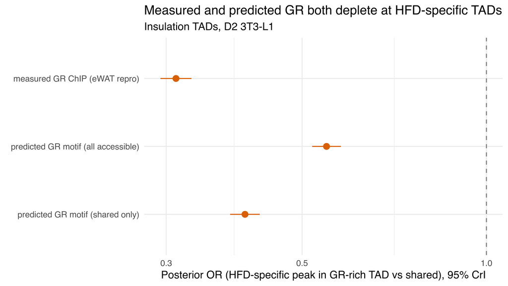

```r
bind_rows(
  per_peak |> filter(caller == "insulation", gr_set == "eWAT_repro") |>
    transmute(set = "measured GR ChIP (eWAT repro)", or_post, cri_lo, cri_hi),
  per_peak_motif |> filter(caller == "insulation") |>
    transmute(set = recode(gr_set,
                GRmotif_all    = "predicted GR motif (all accessible)",
                GRmotif_shared = "predicted GR motif (shared only)"),
              or_post, cri_lo, cri_hi)
) |>
  mutate(set = factor(set, levels = rev(c(
    "measured GR ChIP (eWAT repro)",
    "predicted GR motif (all accessible)",
    "predicted GR motif (shared only)")))) |>
  ggplot(aes(or_post, set)) +
  geom_vline(xintercept = 1, linetype = 2, colour = "grey50") +
  geom_pointrange(aes(xmin = cri_lo, xmax = cri_hi), colour = "#d95f02") +
  scale_x_log10() +
  labs(x = "Posterior OR (HFD-specific peak in GR-rich TAD vs shared), 95% CrI",
       y = NULL, title = "Measured and predicted GR both deplete at HFD-specific TADs",
       subtitle = "Insulation TADs, D2 3T3-L1") +
  theme_minimal(base_size = 12)
```

```r
ggsave(file.path(out_dir, "tad_gr_motif_vs_chip_forest.pdf"), width = 8, height = 4.5)
```

```r
ma <- per_peak_motif |> filter(caller == "insulation", gr_set == "GRmotif_all")
msh <- per_peak_motif |> filter(caller == "insulation", gr_set == "GRmotif_shared")
cat(sprintf(
"**The depletion replicates with motif identity.** HFD-specific peaks are depleted in GR-motif-rich TADs: predicted GR motif (all accessible) posterior OR = %.2f (95%% CrI %.2f–%.2f, P(OR>1) = %.3f); the non-circular **shared-only** GR-motif landscape — which cannot be inflated by the HFD peaks' own motifs — is the *strongest* depletion, OR = %.2f (95%% CrI %.2f–%.2f). Both reproduce in the HiCExplorer caller.\n\n",
  ma$or_post, ma$cri_lo, ma$cri_hi, ma$p_or_gt1, msh$or_post, msh$cri_lo, msh$cri_hi))
```

**The depletion replicates with motif identity.** HFD-specific peaks are depleted in GR-motif-rich TADs: predicted GR motif (all accessible) posterior OR = 0.55 (95% CrI 0.52–0.58, P(OR>1) = 0.000); the non-circular **shared-only** GR-motif landscape — which cannot be inflated by the HFD peaks’ own motifs — is the *strongest* depletion, OR = 0.40 (95% CrI 0.38–0.43). Both reproduce in the HiCExplorer caller.

```r
cat(
"So the measured-vs-predicted GR *discordance* is purely **local** (within-peak motif co-occurrence, OR 1.28) — at the **3D/TAD scale the two agree**: HFD-opened chromatin sits in GR-poor neighborhoods by either measure. This removes the occupancy-dynamics escape hatch (it is not merely that GR ChIP is chow/basal-limited; the unrealized motif *potential* is depleted too) and makes the negative H1 result substantially more robust: HFD remodeling happens in TADs that are GR-poor whether GR is scored by binding or by sequence.\n")
```

So the measured-vs-predicted GR *discordance* is purely **local** (within-peak motif co-occurrence, OR 1.28) — at the **3D/TAD scale the two agree**: HFD-opened chromatin sits in GR-poor neighborhoods by either measure. This removes the occupancy-dynamics escape hatch (it is not merely that GR ChIP is chow/basal-limited; the unrealized motif *potential* is depleted too) and makes the negative H1 result substantially more robust: HFD remodeling happens in TADs that are GR-poor whether GR is scored by binding or by sequence.

# Specificity & structure (follow-ups)

Three questions the depletion raises: (1) is CHD/NCD-opened chromatin instead *enriched* in GR-rich TADs? (2) is HFD-peak abundance per TAD related to TAD structure / the GR compartment at all? (3) does any of this connect open chromatin to GR signaling in 3D? All use the primary insulation TADs, measured eWAT-repro GR (`chip`) and the non-circular shared-only GR motif (`motif`).

```r
tadI <- tads$insulation
tc <- tibble(tad_id = seq_along(tadI), tad_len = width(tadI),
             chip  = countOverlaps(tadI, gr_sets$eWAT_repro),
             motif = countOverlaps(tadI, gr_motif_sets$GRmotif_shared))
assign_tad <- function(pk) findOverlaps(midpoints(pk), tadI, select = "first")

classes  <- c("HFD_specific", "CHD_specific", "shared")
assigned <- setNames(map(classes, ~ assign_tad(atac[[.x]])), classes)

# (1a) in-TAD assignment rate by class — are HFD peaks pushed into inter-TAD gaps?
intad <- tibble(class = classes, n = map_int(assigned, length),
                pct_in_tad = map_dbl(assigned, ~ 100 * mean(!is.na(.x))))
intad
```

| class | n | pct_in_tad |
| --- | --- | --- |
| HFD_specific | 6899 | 96.62270 |
| CHD_specific | 1322 | 97.20121 |
| shared | 53378 | 96.20630 |

```r
# (1b) CHD vs HFD foreground in GR-rich TADs (common shared-peak-defined threshold)
peakf <- imap_dfr(assigned, function(h, k)
  tibble(class = k, tad_id = h) |> filter(!is.na(tad_id))) |>
  left_join(tc, by = "tad_id")

fg_or <- function(metric, fg) {
  thr <- median(filter(peakf, class == "shared")[[metric]])
  d  <- peakf |> filter(class %in% c(fg, "shared")) |> mutate(rich = .data[[metric]] > thr)
  kf <- sum(d$rich[d$class == fg]); nf <- sum(d$class == fg)
  kb <- sum(d$rich[d$class == "shared"]); nb <- sum(d$class == "shared")
  bind_cols(tibble(metric = metric, foreground = fg,
                   pct_fg = 100 * kf / nf, pct_bg = 100 * kb / nb),
            posterior_or(kf, nf, kb, nb))
}
contrast <- bind_rows(
  fg_or("chip", "HFD_specific"),  fg_or("chip", "CHD_specific"),
  fg_or("motif","HFD_specific"),  fg_or("motif","CHD_specific"))
contrast
```

| metric | foreground | pct_fg | pct_bg | or_post | cri_lo | cri_hi | p_or_gt1 |
| --- | --- | --- | --- | --- | --- | --- | --- |
| chip | HFD_specific | 23.52235 | 49.81014 | 0.3099716 | 0.2920769 | 0.3286606 | 0.000000 |
| chip | CHD_specific | 58.13230 | 49.81014 | 1.3985289 | 1.2508046 | 1.5657856 | 1.000000 |
| motif | HFD_specific | 28.57786 | 49.79456 | 0.4034730 | 0.3814980 | 0.4266374 | 0.000000 |
| motif | CHD_specific | 51.82879 | 49.79456 | 1.0846799 | 0.9717639 | 1.2121507 | 0.924975 |

```r
# (2) per-TAD co-localization: does HFD-peak count track GR or the active compartment?
ptcount <- function(k) peakf |> filter(class == k) |> count(tad_id, name = k)
pt <- tc |>
  left_join(ptcount("HFD_specific"), by = "tad_id") |>
  left_join(ptcount("CHD_specific"), by = "tad_id") |>
  left_join(ptcount("shared"),       by = "tad_id") |>
  mutate(across(c(HFD_specific, CHD_specific, shared), ~ tidyr::replace_na(., 0L)))

sp <- function(a, b) cor(pt[[a]], pt[[b]], method = "spearman")
cors <- tibble(
  pair = c("n_HFD ~ GR ChIP", "n_HFD ~ GR motif", "n_HFD ~ n_shared (active)",
           "n_CHD ~ GR ChIP", "n_shared ~ GR ChIP (active TADs GR-rich?)",
           "n_HFD ~ TAD length"),
  spearman = c(sp("HFD_specific","chip"), sp("HFD_specific","motif"),
               sp("HFD_specific","shared"), sp("CHD_specific","chip"),
               sp("shared","chip"), sp("HFD_specific","tad_len")))
cors
```

| pair | spearman |
| --- | --- |
| n_HFD ~ GR ChIP | -0.005136539 |
| n_HFD ~ GR motif | 0.102294975 |
| n_HFD ~ n_shared (active) | 0.097635726 |
| n_CHD ~ GR ChIP | 0.398956247 |
| n_shared ~ GR ChIP (active TADs GR-rich?) | 0.892443367 |
| n_HFD ~ TAD length | 0.414941106 |

```r
# GR depletion survives adjusting for active-chromatin (shared-peak) density
pois_partial <- summary(glm(chip ~ HFD_specific + shared, poisson,
                            offset = log(tad_len), data = pt))$coefficients[
                            c("HFD_specific","shared"), , drop = FALSE]
round(pois_partial, 4)
```

```
             Estimate Std. Error  z value Pr(>|z|)
HFD_specific  -0.1335     0.0016 -84.1685        0
shared         0.0207     0.0001 174.3874        0
```

```r
ch <- contrast |> filter(metric == "chip")
cat(sprintf(
"1. **CHD/NCD is the mirror image.** CHD-specific peaks are *enriched* in GR-rich TADs (measured GR OR = %.2f, %.0f%% vs %.0f%% shared) while HFD is depleted (OR = %.2f) — the same flip seen in the 2D GR-ChIPseq result. It is **not** that HFD peaks fall outside TADs: in-TAD assignment is ~%.0f%% for every class. The difference is *which* TADs.\n",
  ch$or_post[ch$foreground=="CHD_specific"], ch$pct_fg[ch$foreground=="CHD_specific"],
  ch$pct_bg[ch$foreground=="CHD_specific"], ch$or_post[ch$foreground=="HFD_specific"],
  mean(intad$pct_in_tad)))
```

1. **CHD/NCD is the mirror image.** CHD-specific peaks are *enriched* in GR-rich TADs (measured GR OR = 1.40, 58% vs 50% shared) while HFD is depleted (OR = 0.31) — the same flip seen in the 2D GR-ChIPseq result. It is **not** that HFD peaks fall outside TADs: in-TAD assignment is ~97% for every class. The difference is *which* TADs.

```r
cat(sprintf(
"2. **HFD-peak abundance is decoupled from the GR/active compartment.** Per TAD, n_HFD is essentially uncorrelated with GR (ρ = %.2f ChIP, %.2f motif) and only weakly with constitutive accessibility (n_shared ρ = %.2f) — whereas the active compartment itself is strongly GR-rich (n_shared ~ GR ρ = %.2f) and CHD tracks it (n_CHD ~ GR ρ = %.2f). The GR depletion persists after adjusting for active-chromatin density (partial Poisson HFD β = %.3f). So the *number* of HFD sites is not explained by TAD structure — HFD remodeling is a separate, GR-poor distribution, not a denser sampling of the active GR-rich TADs.\n",
  sp("HFD_specific","chip"), sp("HFD_specific","motif"), sp("HFD_specific","shared"),
  sp("shared","chip"), sp("CHD_specific","chip"), pois_partial["HFD_specific","Estimate"]))
```

2. **HFD-peak abundance is decoupled from the GR/active compartment.** Per TAD, n_HFD is essentially uncorrelated with GR (ρ = -0.01 ChIP, 0.10 motif) and only weakly with constitutive accessibility (n_shared ρ = 0.10) — whereas the active compartment itself is strongly GR-rich (n_shared ~ GR ρ = 0.89) and CHD tracks it (n_CHD ~ GR ρ = 0.40). The GR depletion persists after adjusting for active-chromatin density (partial Poisson HFD β = -0.134). So the *number* of HFD sites is not explained by TAD structure — HFD remodeling is a separate, GR-poor distribution, not a denser sampling of the active GR-rich TADs.

```r
cat(
"   *Caveat on “TADs rearranging”:* differential ATAC accessibility is not genomic rearrangement; the relevant question is whether HFD shifts TAD **boundaries**. We cannot test it — there is no HFD-vs-CHD adipocyte Hi-C (only single-condition D2). But TADs are broadly stable across states (loops rewire, domains don't), and the depletion replicates from sequence motifs alone (no Hi-C condition involved), so it is not a TAD-misassignment artifact.\n")
```

*Caveat on “TADs rearranging”:* differential ATAC accessibility is not genomic rearrangement; the relevant question is whether HFD shifts TAD **boundaries**. We cannot test it — there is no HFD-vs-CHD adipocyte Hi-C (only single-condition D2). But TADs are broadly stable across states (loops rewire, domains don’t), and the depletion replicates from sequence motifs alone (no Hi-C condition involved), so it is not a TAD-misassignment artifact.

```r
cat(
"3. **No genome-wide 3D link between HFD chromatin and GR — correct, with one boundary.** At the TAD scale the association is negative, by occupancy and by motif. This tests TAD *co-membership*, not measured enhancer–promoter **loops**; a local 3D link for the 151 composite peaks (Sgk1-like) can still exist inside a globally GR-poor background (Stage-2 H3). The result is fully consistent with GR sensitization running through pre-existing/constitutive GREs in the active GR-rich compartment (mechanism 1), independent of the AP-1-opened HFD program.\n")
```

3. **No genome-wide 3D link between HFD chromatin and GR — correct, with one boundary.** At the TAD scale the association is negative, by occupancy and by motif. This tests TAD *co-membership*, not measured enhancer–promoter **loops**; a local 3D link for the 151 composite peaks (Sgk1-like) can still exist inside a globally GR-poor background (Stage-2 H3). The result is fully consistent with GR sensitization running through pre-existing/constitutive GREs in the active GR-rich compartment (mechanism 1), independent of the AP-1-opened HFD program.

# Fkbp5 locus — the negative-feedback gene lives in the GR-rich compartment

Mechanism 1 (the well-supported arm): HFD ↓Fkbp5 → ↓FKBP51 → more nuclear GR → higher GR output, *without* needing new AP-1 enhancers. If that runs through pre-existing GREs, **Fkbp5 should sit in a GR-rich TAD** (unlike the HFD-opened AP-1 program, which avoids them). Here we place Fkbp5 in the D2 TAD map.

```r
# Fkbp5 mm10 gene body (chr4, minus strand; TSS ≈ 100.067 Mb). NB chr4, not chr17.
fkbp5 <- GRanges("chr4", IRanges(99946313, 100067609))

fkbp5_tad <- imap_dfr(tads, function(tad, caller) {
  host     <- tad[ subjectHits(findOverlaps(fkbp5, tad))[1] ]
  all_chip <- countOverlaps(tad, gr_sets$eWAT_repro)
  all_mot  <- countOverlaps(tad, gr_motif_sets$GRmotif_shared)
  nchip    <- countOverlaps(host, gr_sets$eWAT_repro)
  nmot     <- countOverlaps(host, gr_motif_sets$GRmotif_shared)
  tibble(caller = caller,
         host_tad = sprintf("chr4:%s-%s", start(host), end(host)),
         width_kb = round(width(host) / 1e3),
         gr_chip = nchip, gr_chip_pctile = round(100 * mean(all_chip <= nchip)),
         gr_motif = nmot, gr_motif_pctile = round(100 * mean(all_mot <= nmot)),
         n_HFD_opening = countOverlaps(host, atac$HFD_specific),
         n_CHD_closing = countOverlaps(host, atac$CHD_specific),
         n_shared = countOverlaps(host, atac$shared))
})
fkbp5_tad
```

| caller | host_tad | width_kb | gr_chip | gr_chip_pctile | gr_motif | gr_motif_pctile | n_HFD_opening | n_CHD_closing | n_shared |
| --- | --- | --- | --- | --- | --- | --- | --- | --- | --- |
| insulation | chr4:99877434-100527395 | 650 | 24 | 68 | 5 | 74 | 0 | 0 | 19 |
| hicexplorer | chr4:99927396-100577395 | 650 | 24 | 71 | 5 | 78 | 0 | 0 | 18 |

```r
fi <- fkbp5_tad |> filter(caller == "insulation")
cat(sprintf(
"- **Fkbp5 is in a GR-rich TAD** (%s, %d kb): %d measured GR ChIP peaks = %dth percentile genome-wide; GR motif = %dth percentile. Both callers agree it is GR-rich. This is the GR-competent compartment — the *opposite* side of the genome from the HFD AP-1 program (which is depleted for GR, OR 0.31).\n",
  fi$host_tad, fi$width_kb, fi$gr_chip, fi$gr_chip_pctile, fi$gr_motif_pctile))
```

- **Fkbp5 is in a GR-rich TAD** (chr4:99877434-100527395, 650 kb): 24 measured GR ChIP peaks = 68th percentile genome-wide; GR motif = 74th percentile. Both callers agree it is GR-rich. This is the GR-competent compartment — the *opposite* side of the genome from the HFD AP-1 program (which is depleted for GR, OR 0.31).

```r
cat(sprintf(
"- **The domain is constitutively open, not switching wholesale.** It carries %d shared (constitutive) peaks but %d HFD-specific (opening) and %d strict CHD-specific (closing, |LFC|>1) peaks. So Fkbp5's regulation is *local fine-tuning inside a stable, open, GR-rich domain*, not a domain-scale open→closed switch.\n",
  fi$n_shared, fi$n_HFD_opening, fi$n_CHD_closing))
```

- **The domain is constitutively open, not switching wholesale.** It carries 19 shared (constitutive) peaks but 0 HFD-specific (opening) and 0 strict CHD-specific (closing, |LFC|>1) peaks. So Fkbp5’s regulation is *local fine-tuning inside a stable, open, GR-rich domain*, not a domain-scale open→closed switch.

```r
cat(
"- **The locus does close on HFD, but modestly** (GSE236575 §8a: all 13 Fkbp5-locus ATAC peaks CHD ≥ HFD; 2 significant at FDR<0.05 but |LFC|≈0.7 — below the |LFC|>1 cutoff, hence they fall in \"shared\" not \"CHD-specific\"). The transcript drops more than the chromatin (RNA LFC = −1.29, ~2.4×) — so reduced accessibility is at most a partial driver; the dominant closing peak is AP-1-negative, consistent with loss of tonic activation / a repressor mechanism rather than AP-1-driven collapse.\n")
```

- **The locus does close on HFD, but modestly** (GSE236575 §8a: all 13 Fkbp5-locus ATAC peaks CHD ≥ HFD; 2 significant at FDR<0.05 but |LFC|≈0.7 — below the |LFC|>1 cutoff, hence they fall in “shared” not “CHD-specific”). The transcript drops more than the chromatin (RNA LFC = −1.29, ~2.4×) — so reduced accessibility is at most a partial driver; the dominant closing peak is AP-1-negative, consistent with loss of tonic activation / a repressor mechanism rather than AP-1-driven collapse.

```r
cat(
"- **Verdict on the hypothesis:** the *spatial* premise holds — Fkbp5 sits exactly where a GR-feedback gene should, in the NCD-open, GR-rich compartment, and the locus does close on HFD. But it is a **local, modest** chromatin effect within a stable domain, and the transcriptional suppression exceeds the accessibility change. So \"open on NCD → closed on HFD\" is directionally supported as a *contributing* mechanism, layered on top of (not replacing) the transcriptional/feedback logic: ↓Fkbp5 → ↓FKBP51 → ↑nuclear GR → ↑GR output. This is the clean mirror image of the genome-wide result — the GR-feedback machinery is in the GR-rich/closing compartment; the AP-1 opening program is in the GR-poor/opening compartment. Two compartments, two mechanisms.\n")
```

- **Verdict on the hypothesis:** the *spatial* premise holds — Fkbp5 sits exactly where a GR-feedback gene should, in the NCD-open, GR-rich compartment, and the locus does close on HFD. But it is a **local, modest** chromatin effect within a stable domain, and the transcriptional suppression exceeds the accessibility change. So “open on NCD → closed on HFD” is directionally supported as a *contributing* mechanism, layered on top of (not replacing) the transcriptional/feedback logic: ↓Fkbp5 → ↓FKBP51 → ↑nuclear GR → ↑GR output. This is the clean mirror image of the genome-wide result — the GR-feedback machinery is in the GR-rich/closing compartment; the AP-1 opening program is in the GR-poor/opening compartment. Two compartments, two mechanisms.

# Decision

```r
prim <- per_peak |> filter(caller == "insulation", gr_set == "eWAT_repro")
pois <- tad_level  |> filter(caller == "insulation", gr_set == "eWAT_repro")
cat(sprintf(
"- **Per-peak (primary, eWAT strain-reproducible GR):** %.1f%% of HFD-specific vs %.1f%% of shared peaks sit in a GR-rich TAD → Fisher OR = %.2f (95%% CI %.2f–%.2f, p = %.2g); posterior OR = %.2f (95%% CrI %.2f–%.2f), P(OR>1) = %.3f; width/length-adjusted OR = %.2f (p = %.2g).\n",
  prim$pct_fg, prim$pct_bg, prim$or_fisher, prim$ci_lo, prim$ci_hi, prim$p_fisher,
  prim$or_post, prim$cri_lo, prim$cri_hi, prim$p_or_gt1, prim$or_adj, prim$p_adj))
```

- **Per-peak (primary, eWAT strain-reproducible GR):** 24.8% of HFD-specific vs 51.5% of shared peaks sit in a GR-rich TAD → Fisher OR = 0.31 (95% CI 0.29–0.33, p = 0); posterior OR = 0.31 (95% CrI 0.29–0.33), P(OR>1) = 0.000; width/length-adjusted OR = 0.27 (p = 0).

```r
cat(sprintf(
"- **TAD-level Poisson:** each additional HFD-specific peak in a TAD multiplies the expected GR-peak count by %.3f (IRR, 95%% CI %.3f–%.3f, p = %.2g).\n",
  pois$irr, pois$irr_lo, pois$irr_hi, pois$p))
```

- **TAD-level Poisson:** each additional HFD-specific peak in a TAD multiplies the expected GR-peak count by 0.881 (IRR, 95% CI 0.878–0.883, p = 0).

```r
mo <- per_peak_motif |> filter(caller == "insulation", gr_set == "GRmotif_shared")
cat(sprintf(
"- **Predicted GR motif (concordance check):** the depletion replicates with motif identity — HFD-specific peaks in GR-motif-rich TADs, shared-only landscape posterior OR = %.2f (95%% CrI %.2f–%.2f). Measured and predicted GR agree at the TAD scale.\n",
  mo$or_post, mo$cri_lo, mo$cri_hi))
```

- **Predicted GR motif (concordance check):** the depletion replicates with motif identity — HFD-specific peaks in GR-motif-rich TADs, shared-only landscape posterior OR = 0.40 (95% CrI 0.38–0.43). Measured and predicted GR agree at the TAD scale.

```r
verdict <- if (prim$or_post > 1.5 & prim$p_or_gt1 > 0.95) {
  "**OR > 1.5 → H1 supported.** Proceed to Stage 2 (ABC enhancer-gene predictions) and reframe Arm 2 around the 3D-contact mechanism."
} else if (prim$cri_lo < 1 & prim$cri_hi > 1) {
  "**OR ≈ 1 → H1 not supported.** The local 151-peak claim stands; Stage 2 still informative for H3 (do the 151 composite peaks cluster in metabolic TADs?)."
} else if (prim$or_post < 1) {
  "**OR < 1 → GR-rich TADs are depleted of HFD-specific peaks.** HFD remodels chromatin preferentially in non-GR TADs — mechanistically interesting; report as such."
} else "Intermediate — inspect the full table and the second caller before deciding."
cat("- **Verdict:** ", verdict, "\n", sep = "")
```

- **Verdict:** **OR < 1 → GR-rich TADs are depleted of HFD-specific peaks.** HFD remodels chromatin preferentially in non-GR TADs — mechanistically interesting; report as such.

# Caveats

1. **D2, not mature adipocyte.** GSE95533 Hi-C exists only at D0/4h/D2 — there is no D6/D7 mature-adipocyte Hi-C. D2 (early differentiation, post-induction) is the most adipocyte-committed Hi-C available. TAD boundaries are largely invariant across adipogenesis (Siersbaek 2017: promoter loops rewire while domains are broadly stable), so D2 TADs are acceptable for the coarse “GR-rich-TAD” question; they limit fine-grained per-loop claims.
2. **3T3-L1 is a cell line**, not primary eWAT adipocytes; same TAD-invariance argument applies at the domain scale.
3. **TAD-caller dependence.** Two independent callers are run (cooltools insulation primary, HiCExplorer sensitivity); the decision is read off the primary but should reproduce in the sensitivity caller.
4. **mm9 → mm10 liftover.** TADs are called in native mm9 and lifted; lift recovery is reported by the pipeline (`LIFTOVER_TADS` log).
5. **GR-set caveats carry over** from GR-ChIPseq: mouse = chow (no HFD/dex induction); human = cross-species dex in vitro; union sets over-permissive. eWAT strain-reproducible is the primary readout. ```